# de Jong et al (2018)

# QTL mapping in MAGIC lines

This document contains the code to carry out QTL mapping in the MAGIC lines.

We use the `happy.hbrem` package available from http://mtweb.cs.ucl.ac.uk/mus/www/magic/ and a custom R package, which is available from https://github.com/tavareshugo/MagicHelpR.

Details on how to use our package are available on its [documentation](https://tavareshugo.github.io/MagicHelpR/articles/introduction.html).

We first illustrate the basic QTL model fitting routine we use.

```r
library(tidyverse)
library(patchwork)
library(MagicHelpR) # install with devtools::install_github("tavareshugo/MagicHelpR")

# Change ggplot2 default aesthetics
theme_set(theme_classic() +
            theme(panel.grid = element_blank(),
                  text = element_text(size = 8),
                  plot.title = element_text(hjust = -0.07, size = 10, face = "bold",
                                            margin = margin(t = -5, b = 1)),
                  plot.subtitle = element_text(size = 10, hjust = 0.5)))
```

## Read data

### Phenotype data

We first read the phenotype data used for QTL mapping. This is using a table with all traits summarised per line (average trait values and plasticity).

```r
# Read CSV file
magic_plas <- read_csv("../../data/phenotypes/magic_plasticity.csv")

# Keep only data for main traits of interest
magic_plas <- magic_plas %>%
  select(id_kover, matches("height|bolt|totalbr"), -matches("rdpi"))
```

These are the trait distributions for all lines. We highlight those that flower early (< 25 days on LN), because those are the ones we focus on for the QTL mapping:

[figure not shown]

```r
magic_plas %>%
  mutate(early_flower = bolt_mean_ln < 25) %>%
  gather("trait", "value", -id_kover, -early_flower) %>%
  group_by(trait) %>%
  mutate(value_standard = (value - mean(value))/sd(value)) %>%
  ggplot(aes(value_standard, fill = early_flower)) +
  geom_histogram() +
  facet_wrap(~ trait, scales = "free") +
  labs(x = "Standard Score", y = "Count", fill = "Early flowering\n(<25 days LN)")
```

From the Q-Q plots, we can see all traits fit well within a normal distribution, except flowering time when using all lines:

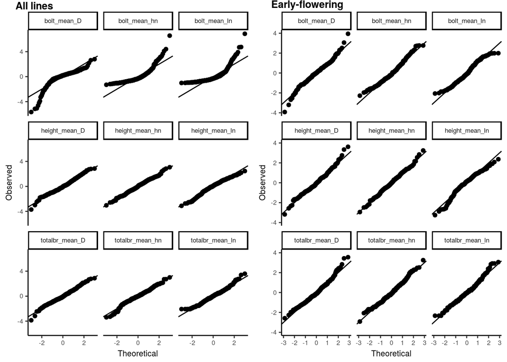

```r
# Q-Q plots for all lines
p1 <- magic_plas %>%
  gather("trait", "value", -id_kover) %>%
  group_by(trait) %>%
  mutate(value_standard = (value - mean(value))/sd(value)) %>%
  ggplot(aes(sample = value_standard)) +
  geom_qq() +
  facet_wrap(~ trait) +
  geom_abline() +
  labs(x = "Theoretical", y = "Observed", title = "All lines")

# Q-Q plots for early-flowering
p2 <- magic_plas %>%
  filter(bolt_mean_ln < 25) %>%
  gather("trait", "value", -id_kover) %>%
  group_by(trait) %>%
  mutate(value_mean = mean(value), value_standard = (value - mean(value))/sd(value)) %>%
  ggplot(aes(sample = value_standard)) +
  geom_qq() +
  facet_wrap(~ trait) +
  geom_abline() +
  labs(x = "Theoretical", y = "Observed", title = "Early-flowering")

p1 + p2
```

We continue with the early-flowering lines only:

```r
magic_plas <- magic_plas %>% filter(bolt_mean_ln < 25)
nrow(magic_plas)
```

```
## [1] 258
```

### Genotype data

The genotype data is available from http://mtweb.cs.ucl.ac.uk/mus/www/magic/

We use our own custom R package to download, tidy, and read these data for QTL mapping. Details of how to use these functions can be found in the package’s introduction vignette (https://github.com/tavareshugo/MagicHelpR).

Here, we download the genotype data and read it into R:

```r
# Download and tidy genotype data
if(!dir.exists("./temp_data")) dir.create("./temp_data")
downloadArabMagic(save_dir = "./temp_data/magic_genotypes/", tidy = TRUE)

# Read genotypes and add phenotypes
magic_gen <- magicFounderReconstruct("./temp_data/magic_genotypes/",
                                     phenotypes = magic_plas, id = "id_kover")
```

```
## mindist: 1e-05
## datafile ./temp_data/magic_genotypes//all_chr.MAGIC.happy.data allelesfile ./temp_data/magic_genotypes//all_chr.MAGIC.happy.alleles gen 7
## genotype phase: unknown
## Reading phenotype and genotype data from ped file ./temp_data/magic_genotypes//all_chr.MAGIC.happy.data
## Number of individuals: 703
## Number of markers:     1259
## Number of strains:     19
## Use Parents:           no
## Number of subjects with two parents: 0
## Number of parents in nuclear families: 0
## null model mean nan var nan
## assuming haploid(inbred) genotypes
## datafile ./temp_data/magic_genotypes//all_chr.MAGIC.happy.data allelesfile ./temp_data/magic_genotypes//all_chr.MAGIC.happy.alleles gen 7
```

We now have an object containg genotype and phenotype information for all our scored MAGIC lines:

```r
magic_gen
```

```
## Object of class MagicGenPhen
## 258 MAGIC lines with a phenotype.
## There are 9 phenotypes:
##  height_mean_hn totalbr_mean_hn bolt_mean_hn height_mean_ln totalbr_mean_ln bolt_mean_ln height_mean_D totalbr_mean_D bolt_mean_D
## Using genotypes for 1258 markers.
```

## QTL mapping

We exemplify the routine used for QTL mapping here. For the data presented in the paper, we used an script that was run non-interactively (this script is available upon request).

As an example, we use height, known to have a major QTL in the *Erecta* gene.

```r
# Scan for QTL
height_ln <- scanQtl(magic_gen, "height_mean_ln")
```

```
## F-test comparing the models:
##   H1: height_mean_ln ~ GEN
##   H0: height_mean_ln ~ 1
```

```
## Elapsed time: 20 seconds
```

This returns a `data.frame` object with the following results:

| marker | map | bp | chromosome | f | df1 | df2 | p | r2_h1 | r2_h0 |
| --- | --- | --- | --- | --- | --- | --- | --- | --- | --- |
| AGL24_2913 | 52.79989 | 12671962 | 4 | 1.651897 | 18 | 239 | 0.0490247 | 0.0436645 | 0 |
| AGL24_3240 | 52.79853 | 12671635 | 4 | 1.654103 | 18 | 239 | 0.0485756 | 0.0438058 | 0 |
| AGL24_3515 | 52.79738 | 12671360 | 4 | 1.625921 | 18 | 239 | 0.0546011 | 0.0419977 | 0 |
| AGL24_3653 | 52.79681 | 12671222 | 4 | 1.625586 | 18 | 239 | 0.0546768 | 0.0419761 | 0 |
| AGL24_3913 | 52.79574 | 12670965 | 4 | 1.625521 | 18 | 239 | 0.0546913 | 0.0419720 | 0 |
| AGL24_4208 | 52.79454 | 12670678 | 4 | 1.628571 | 18 | 239 | 0.0540073 | 0.0421680 | 0 |

We can produce the usual manhattan plot like so:

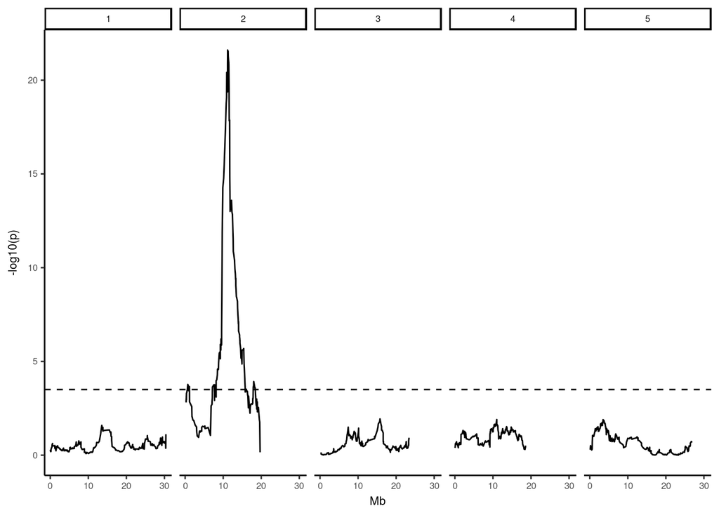

```r
ggplot(height_ln, aes(bp/1e6, -log10(p))) +
  geom_line() +
  facet_grid(~ chromosome) +
  labs(x = "Mb") +
  geom_hline(yintercept = 3.5, linetype = "dashed")
```

## QTL figures

The above approach was used to do association mapping for all our traits of interest. Here, we read a CSV file containg all the results that were produced with our custom script. These also include estimates of (computationally expensive) permutation-based p-values that control for the familywise error rate due to multiple-testing of ~1K variants.

```r
qtl_results <- read_csv("../../data/qtl_magic/qtl_scans_prob.csv", guess_max = Inf)
head(qtl_results)
```

```
## # A tibble: 6 x 15
##   marker  trait p_snp p_perm_snp   map     bp chromosome     f   df1   df2
##   <chr>   <chr> <dbl>      <dbl> <dbl>  <int>      <int> <dbl> <int> <int>
## 1 AGL24_… bolt… 0.683       1.00  52.8 1.27e⁷          4 0.930    18   239
## 2 AGL24_… bolt… 0.404       1.00  52.8 1.27e⁷          4 0.948    18   239
## 3 AGL24_… bolt… 0.404       1.00  52.8 1.27e⁷          4 0.938    18   239
## 4 AGL24_… bolt… 0.404       1.00  52.8 1.27e⁷          4 0.938    18   239
## 5 AGL24_… bolt… 0.404       1.00  52.8 1.27e⁷          4 0.938    18   239
## 6 AGL24_… bolt… 0.963       1.00  52.8 1.27e⁷          4 0.940    18   239
## # ... with 5 more variables: p <dbl>, r2_h1 <dbl>, r2_h0 <dbl>,
## #   p_perm <dbl>, covariate <chr>
```

### Figure S5

QTL plot for height:

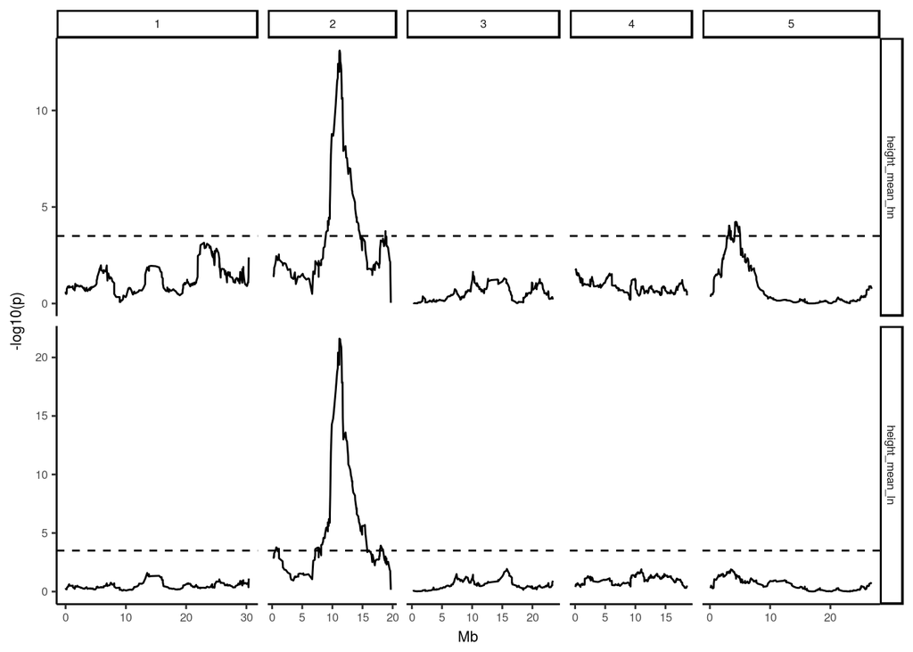

```r
#pdf("./figures/figureS5.pdf", width = 7, height = 3)
qtl_results %>%
  filter(grepl("height", trait)) %>%
  ggplot(aes(bp/1e6, -log10(p))) +
  geom_line() +
  facet_grid(trait ~ chromosome, scales = "free", space = "free_x") +
  labs(x = "Mb") +
  geom_hline(yintercept = 3.5, linetype = "dashed")
```

```r
#dev.off()
```

This plot was further annotated manually in inkscape.

Notice that QTL on Chr5 for HN is due to a correlation between the two traits:

```r
cor.test(magic_plas$height_mean_hn, magic_plas$bolt_mean_hn, method = "pearson")
```

```
##
##  Pearson's product-moment correlation
##
## data:  magic_plas$height_mean_hn and magic_plas$bolt_mean_hn
## t = 10.551, df = 256, p-value < 2.2e-16
## alternative hypothesis: true correlation is not equal to 0
## 95 percent confidence interval:
##  0.4592521 0.6302546
## sample estimates:
##       cor
## 0.5505016
```

```r
height_hn <- scanQtl(magic_gen, phenotype = "height_mean_hn", covariates = "bolt_mean_hn")
```

```
## F-test comparing the models:
##   H1:height_mean_hn ~ GEN + bolt_mean_hn
##   H0:height_mean_hn ~ bolt_mean_hn
```

```
## Elapsed time: 23 seconds
```

[figure not shown]

```r
qtl_results %>%
  filter(grepl("height", trait)) %>%
  ggplot(aes(bp/1e6, -log10(p))) +
  geom_line() +
  facet_grid(trait ~ chromosome, scales = "free", space = "free_x") +
  labs(x = "Mb") +
  geom_hline(yintercept = 3.5, linetype = "dashed")
```

### Figure 8

QTL plot for flowering:

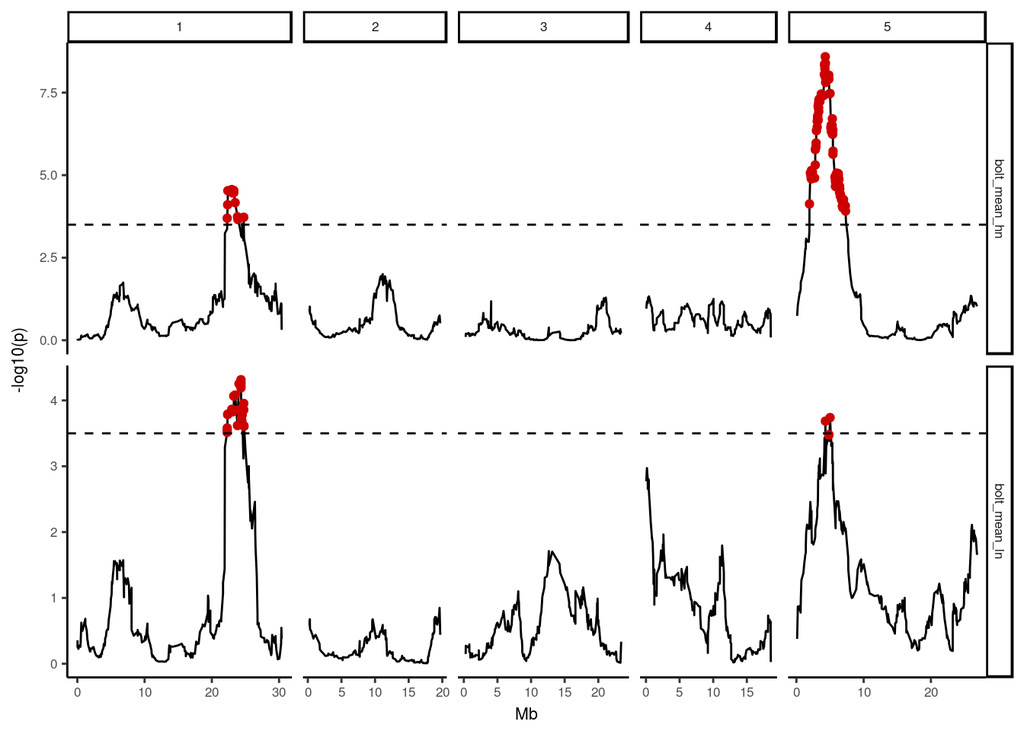

```r
qtl_results %>%
  filter(grepl("bolt", trait)) %>%
  mutate(sig = ifelse(p_perm < 0.05, -log10(p), NA)) %>%
  ggplot(aes(bp/1e6, -log10(p))) +
  geom_line() +
  geom_point(aes(y = sig), colour = "red3") +
  facet_grid(trait ~ chromosome, scales = "free", space = "free_x") +
  labs(x = "Mb") +
  geom_hline(yintercept = 3.5, linetype = "dashed")
```

QTL plot for branching:

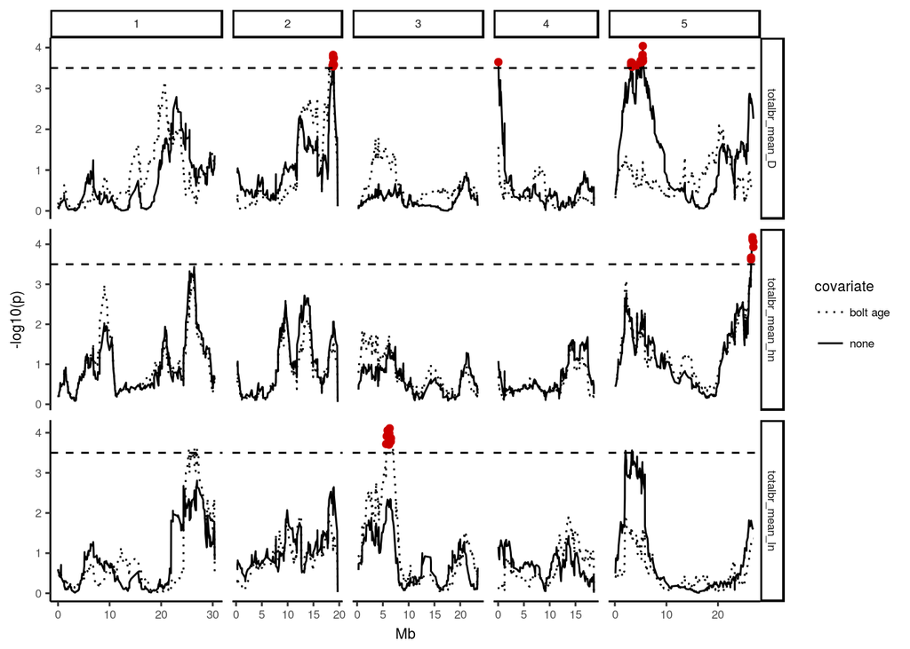

```r
# Highlight peaks with permutation-based p-value < 0.05
qtl_results %>%
  filter(grepl("totalbr", trait)) %>%
  mutate(sig = ifelse(p_perm < 0.05, -log10(p), NA)) %>%
  ggplot(aes(bp/1e6, -log10(p))) +
  geom_line(aes(linetype = covariate)) +
  geom_point(aes(y = sig), colour = "red3") +
  facet_grid(trait ~ chromosome, scales = "free", space = "free_x") +
  labs(x = "Mb") +
  geom_hline(yintercept = 3.5, linetype = "dashed") +
  scale_linetype_manual(values = c(3, 1))
```

Figure for paper (further annotated in inkscape):

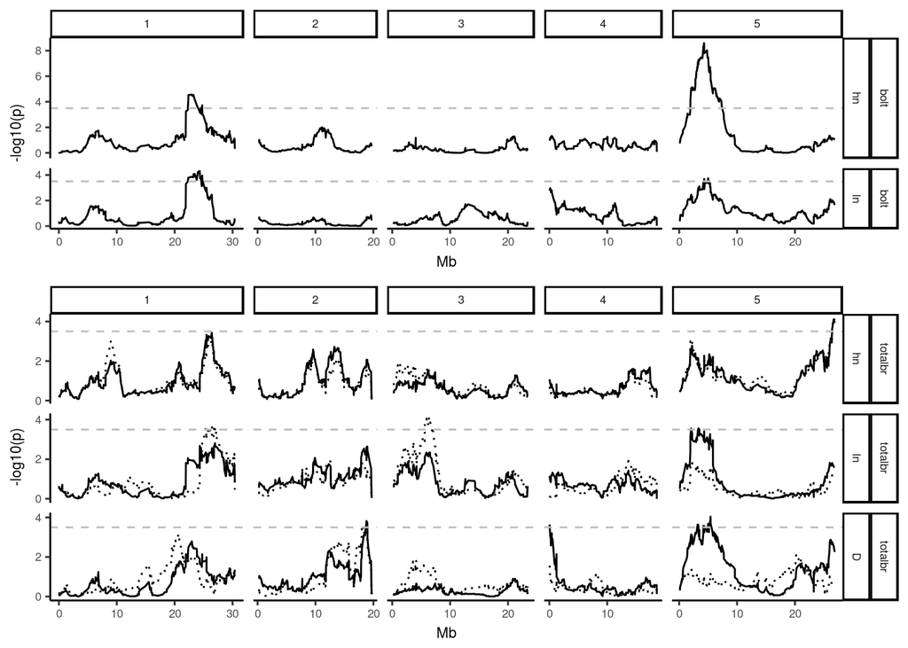

```r
p1 <- qtl_results %>%
  filter(grepl("bolt", trait)) %>%
  separate(trait, c("trait", "stat", "nitrate"), sep = "_") %>%
  mutate(nitrate = factor(nitrate, levels = c("hn", "ln", "D"))) %>%
  ggplot(aes(bp/1e6, -log10(p))) +
  geom_line() +
  facet_grid(trait + nitrate ~ chromosome, scales = "free", space = "free") +
  labs(x = "Mb") +
  geom_hline(yintercept = 3.5, linetype = "dashed", colour = "grey") +
  theme(panel.grid = element_blank()) +
  scale_y_continuous(breaks = seq(0, 10, 2)) +
  scale_x_continuous(breaks = seq(0, 30, 10))

p2 <- qtl_results %>%
  filter(grepl("totalbr", trait)) %>%
  separate(trait, c("trait", "stat", "nitrate"), sep = "_") %>%
  mutate(nitrate = factor(nitrate, levels = c("hn", "ln", "D"))) %>%
  ggplot(aes(bp/1e6, -log10(p))) +
  geom_line(aes(linetype = covariate)) +
  facet_grid(trait + nitrate ~ chromosome, scales = "free", space = "free") +
  labs(x = "Mb") +
  geom_hline(yintercept = 3.5, linetype = "dashed", colour = "grey") +
  theme(panel.grid = element_blank()) +
  scale_linetype_manual(values = c(3, 1)) +
  theme(legend.position = "none") +
  scale_y_continuous(breaks = seq(0, 10, 2)) +
  scale_x_continuous(breaks = seq(0, 30, 10))

#pdf("./figures/figure8.pdf", width = 7, height = 6)
p1 + p2 + plot_layout(ncol = 1, heights = c(2/5, 3/5))
```

```r
#dev.off()
```

Correlation between total branches and flowering time, to include in figure legend:

```r
magic_plas <- read_rds("../../data/phenotypes/magic_plasticity.rds") %>%
  filter(bolt_mean_ln < 25)

# Correlation between branching and bolting
cor.test(magic_plas$totalbr_mean_D, magic_plas$bolt_mean_ln, method = "pearson")
```

```
##
##  Pearson's product-moment correlation
##
## data:  magic_plas$totalbr_mean_D and magic_plas$bolt_mean_ln
## t = 14.413, df = 256, p-value < 2.2e-16
## alternative hypothesis: true correlation is not equal to 0
## 95 percent confidence interval:
##  0.5958781 0.7316211
## sample estimates:
##       cor
## 0.6692973
```

```r
cor.test(magic_plas$totalbr_mean_ln, magic_plas$bolt_mean_ln, method = "pearson")
```

```
##
##  Pearson's product-moment correlation
##
## data:  magic_plas$totalbr_mean_ln and magic_plas$bolt_mean_ln
## t = -11.441, df = 256, p-value < 2.2e-16
## alternative hypothesis: true correlation is not equal to 0
## 95 percent confidence interval:
##  -0.6571130 -0.4946819
## sample estimates:
##        cor
## -0.5816667
```

```r
cor.test(magic_plas$totalbr_mean_hn, magic_plas$bolt_mean_hn, method = "pearson")
```

```
##
##  Pearson's product-moment correlation
##
## data:  magic_plas$totalbr_mean_hn and magic_plas$bolt_mean_hn
## t = 5.1103, df = 256, p-value = 6.297e-07
## alternative hypothesis: true correlation is not equal to 0
## 95 percent confidence interval:
##  0.1891554 0.4111019
## sample estimates:
##       cor
## 0.3042521
```

## Estimating QTL effect sizes - Fig. 10

The QTL effect can be estimated by using the phenotype imputation method detailed in [Kover .. Mott (2009)](http://journals.plos.org/plosgenetics/article?id=10.1371/journal.pgen.1000551).

For example, for the *Erecta* peak for height shown above, this could be done like so:

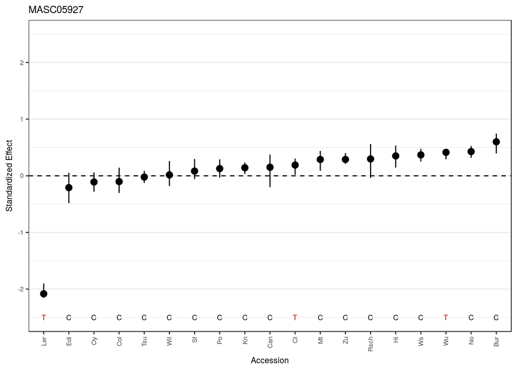

```r
# Get peak marker name
hgt_ln_2 <- qtl_results %>% filter(trait == "height_mean_ln") %>%
  arrange(p) %>% slice(1) %>% .$marker

# Make a plot, adding SNP alleles of each founder acccession
p1 <- estimateFounderEffect(magic_gen, "height_mean_ln", hgt_ln_2) %>%
  ggplot(aes(accession, effect_mean)) +
  geom_hline(yintercept = 0, linetype = "dashed") +
  geom_pointrange(aes(ymax = effect_up, ymin = effect_lo)) +
  geom_text(data = getFounderGenotypes(magic_gen)[[hgt_ln_2]],
            aes(y = -2.5, label = allele, colour = allele), size = 2.5) +
  theme_bw() +
  theme(text = element_text(size = 8), legend.position = "none", axis.text.x = element_text(angle = 90, hjust = 1, vjust = 0.5),
        panel.grid.major.x = element_blank()) +
  scale_y_continuous(breaks = -5:5, limits = c(-2.5, 2.5)) +
  scale_colour_manual(values = c("black", "red3")) +
  labs(x = "Accession", y = "Standardized Effect", title = hgt_ln_2)
p1
```

And we can clearly see that the *Ler* allele is associated with particularly small plants (~2 standard deviations below the overall average).

We also annotated the plot with the SNP alleles of each founder accession. This reveals how the *Ct* accession actually shares an allele with *Ler*, despite having a clearly different contribution to the phenotype.

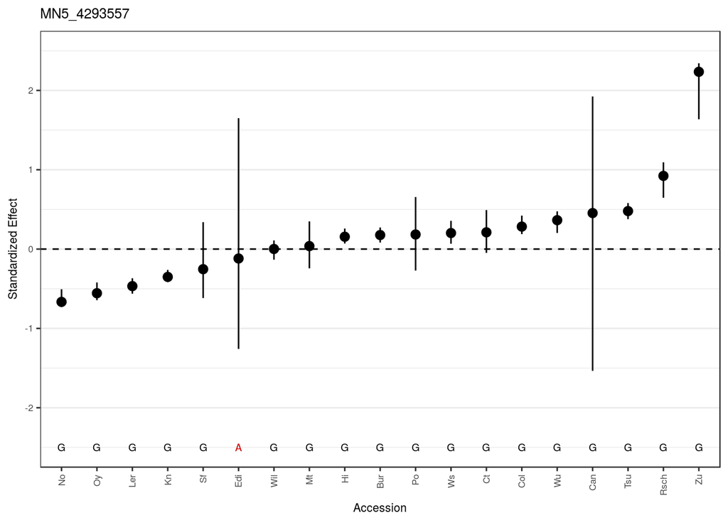

```r
ft_hn_5 <- qtl_results %>%
  filter(trait == "bolt_mean_hn" & chromosome == 5) %>%
  arrange(p) %>% slice(1) %>% .$marker

p2 <- estimateFounderEffect(magic_gen, "bolt_mean_hn", ft_hn_5) %>%
  ggplot(aes(accession, effect_mean)) +
  geom_hline(yintercept = 0, linetype = "dashed") +
  geom_pointrange(aes(ymax = effect_up, ymin = effect_lo)) +
  geom_text(data = getFounderGenotypes(magic_gen)[[ft_hn_5]],
            aes(y = -2.5, label = allele, colour = allele), size = 2.5) +
  theme_bw() +
  theme(text = element_text(size = 8), legend.position = "none", axis.text.x = element_text(angle = 90, hjust = 1, vjust = 0.5),
        panel.grid.major.x = element_blank()) +
  scale_y_continuous(breaks = -5:5, limits = c(-2.5, 2.5)) +
  scale_colour_manual(values = c("red3", "black")) +
  labs(x = "Accession", y = "Standardized Effect", title = ft_hn_5)
p2
```

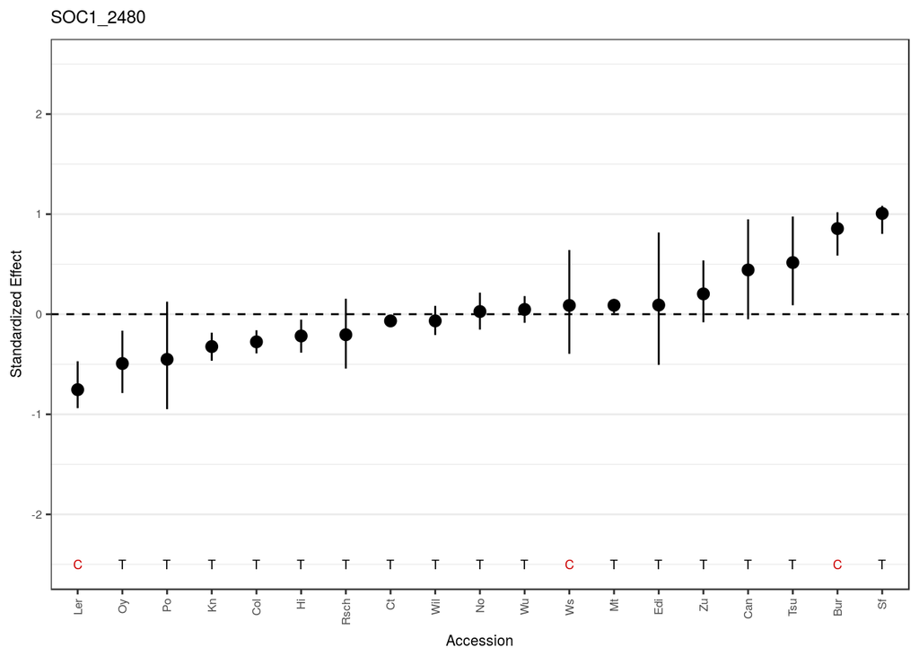

```r
totalbr_d_2 <- qtl_results %>%
  filter(trait == "totalbr_mean_D" & chromosome == 2) %>%
  arrange(p) %>% slice(1) %>% .$marker

p3 <- estimateFounderEffect(magic_gen, "totalbr_mean_D", totalbr_d_2) %>%
  ggplot(aes(accession, effect_mean)) +
  geom_hline(yintercept = 0, linetype = "dashed") +
  geom_pointrange(aes(ymax = effect_up, ymin = effect_lo)) +
  geom_text(data = getFounderGenotypes(magic_gen)[[totalbr_d_2]],
            aes(y = -2.5, label = allele, colour = allele), size = 2.5) +
  theme_bw() +
  theme(text = element_text(size = 8), legend.position = "none", axis.text.x = element_text(angle = 90, hjust = 1, vjust = 0.5),
        panel.grid.major.x = element_blank()) +
  scale_y_continuous(breaks = -5:5, limits = c(-2.5, 2.5)) +
  scale_colour_manual(values = c("red3", "black")) +
  labs(x = "Accession", y = "Standardized Effect", title = totalbr_d_2)
p3
```

This shows the effect of the main QTL for height, shoot branching plasticity and flowering QTL on chr 5 presented in Fig 10:

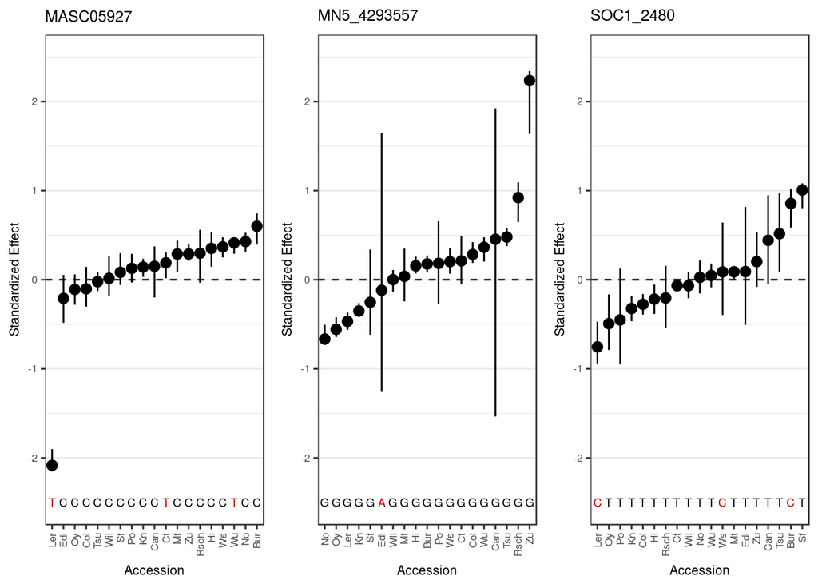

```r
#pdf("./figures/figure10.pdf", height = 3, width = 7.5)
p1 + p2 + p3
```

```r
#dev.off()
```

Also get the effect of the two QTL that were observed with added covariate for branching on LN:

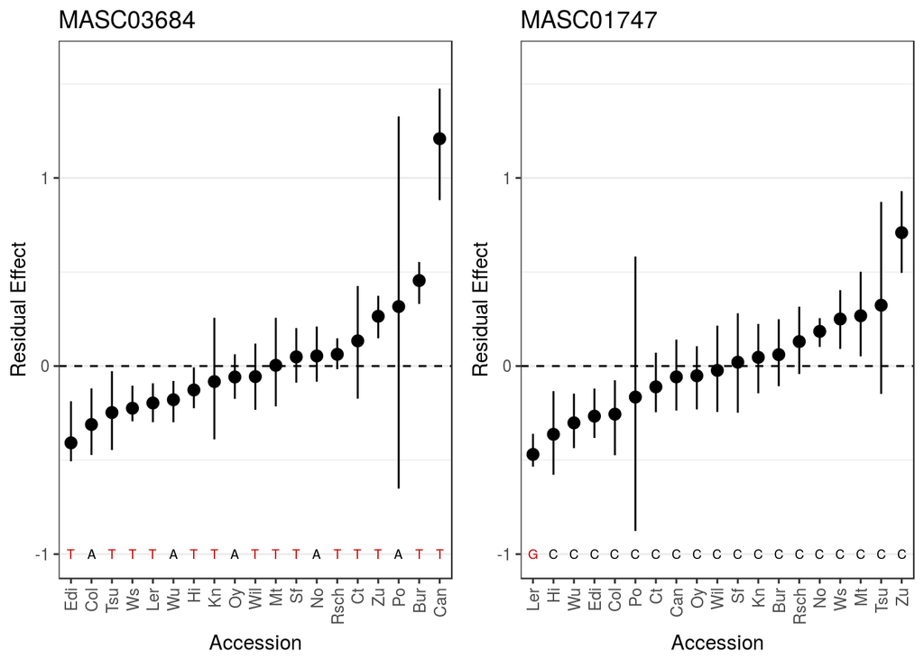

```r
# Get peak marker name
totalbr_ln_cov <- qtl_results %>%
  filter(trait == "totalbr_mean_ln" & covariate == "bolt age" & chromosome %in% c(1, 3)) %>%
  group_by(chromosome) %>%
  arrange(p) %>% slice(1) %>% .$marker

# Make a plot, adding SNP alleles of each founder acccession
p1 <- estimateFounderEffect(magic_gen, "totalbr_mean_ln", totalbr_ln_cov[1],
                            standardised = FALSE, covariates = "bolt_mean_ln") %>%
  ggplot(aes(accession, effect_mean)) +
  geom_hline(yintercept = 0, linetype = "dashed") +
  geom_pointrange(aes(ymax = effect_up, ymin = effect_lo)) +
  geom_text(data = getFounderGenotypes(magic_gen)[[totalbr_ln_cov[1]]],
            aes(y = -1, label = allele, colour = allele), size = 2.5) +
  theme_bw() +
  theme(legend.position = "none", axis.text.x = element_text(angle = 90, hjust = 1, vjust = 0.5),
        panel.grid.major.x = element_blank()) +
  scale_colour_manual(values = c("black", "red3")) +
  labs(x = "Accession", y = "Residual Effect", title = totalbr_ln_cov[1]) +
  scale_y_continuous(breaks = seq(-1, 2, 1), limits = c(-1, 1.6))
# Make a plot, adding SNP alleles of each founder acccession
p2 <- estimateFounderEffect(magic_gen, "totalbr_mean_ln", totalbr_ln_cov[2],
                            standardised = FALSE, covariates = "bolt_mean_ln") %>%
  ggplot(aes(accession, effect_mean)) +
  geom_hline(yintercept = 0, linetype = "dashed") +
  geom_pointrange(aes(ymax = effect_up, ymin = effect_lo)) +
  #geom_label(aes(label = n)) +
  geom_text(data = getFounderGenotypes(magic_gen)[[totalbr_ln_cov[2]]],
            aes(y = -1, label = allele, colour = allele), size = 2.5) +
  theme_bw() +
  theme(legend.position = "none", axis.text.x = element_text(angle = 90, hjust = 1, vjust = 0.5),
        panel.grid.major.x = element_blank()) +
  scale_colour_manual(values = c("black", "red3")) +
  labs(x = "Accession", y = "Residual Effect", title = totalbr_ln_cov[2]) +
  scale_y_continuous(breaks = seq(-1, 2, 1), limits = c(-1, 1.6))
p1 + p2
```

## Extra: comparing haplotype and SNP-based method

```r
# Make the QTL scan
height_ln_snp <- scanQtl(magic_gen, "height_mean_ln", method = "allele")
```

```
## F-test comparing the models:
##   H1: height_mean_ln ~ GEN
##   H0: height_mean_ln ~ 1
```

```
## Elapsed time: 5 seconds
```

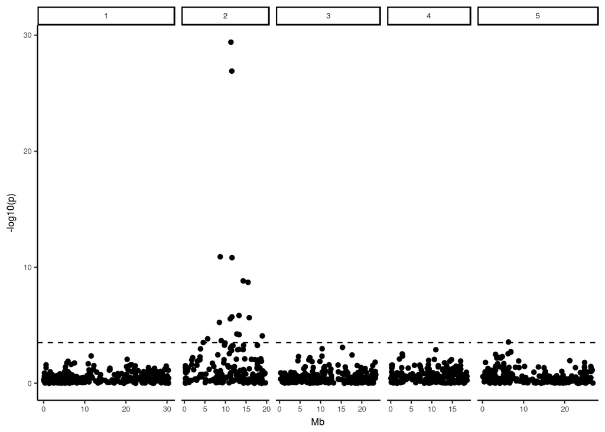

```r
# Produce the plot
ggplot(height_ln_snp, aes(bp/1e6, -log10(p))) +
  geom_point() +
  facet_grid(~ chromosome, scales = "free_x", space = "free_x") +
  labs(x = "Mb") +
  geom_hline(yintercept = 3.5, linetype = "dashed")
```

Since the table already contains the p-values for the test using SNP genotypes, we can plot them overlapping the probability-based genotypes.

The example below demonstrates how the haplotype-based method of mapping gives peaks that do not always coincide with SNP-based method:

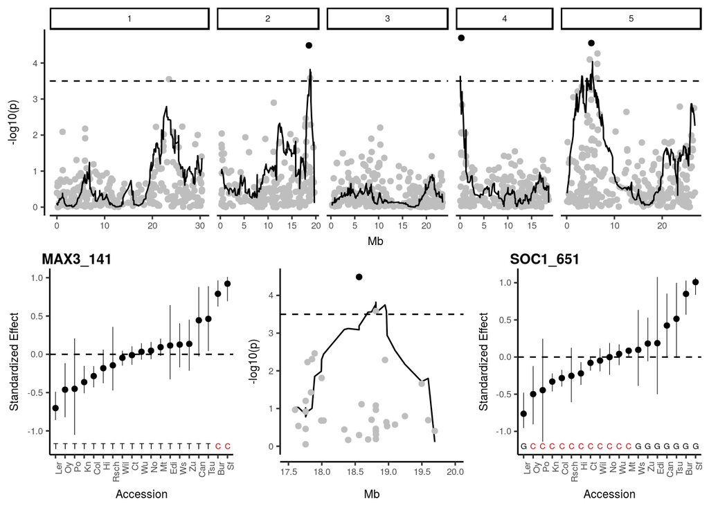

```r
# Manhattan plot with two QTL fitting routines
p1 <- qtl_results %>%
  filter(trait == "totalbr_mean_D" & covariate == "none") %>%
  mutate(sig = ifelse(p_perm_snp < 0.05, -log10(p_snp), NA)) %>%
  ggplot(aes(bp/1e6, -log10(p))) +
  geom_point(aes(y = -log10(p_snp)), colour = "grey") +
  geom_point(aes(y = sig)) +
  #geom_point(data = qtl_snp2, aes(y = sig), colour = "red3") +
  geom_line() +
  facet_grid( ~ chromosome, scales = "free", space = "free_x") +
  labs(x = "Mb") +
  geom_hline(yintercept = 3.5, linetype = "dashed") +
  theme(panel.grid = element_blank())

# Zoomed-in version of previous plot
p2 <- qtl_results %>%
  filter(trait == "totalbr_mean_D" & chromosome == 2 & covariate == "none") %>%
  mutate(sig = ifelse(p_perm_snp < 0.05, -log10(p_snp), NA)) %>%
  ggplot(aes(bp/1e6, -log10(p))) +
  #geom_point(data = qtl_snp2, aes(y = sig), colour = "red3") +
  geom_line() +
  geom_point(aes(y = -log10(p_snp)), colour = "grey") +
  geom_point(aes(y = sig)) +
  labs(x = "Mb") +
  geom_hline(yintercept = 3.5, linetype = "dashed") +
  theme(panel.grid = element_blank()) +
  xlim(17.5, 20)

# Example of SNP effect
p3 <- estimateFounderEffect(magic_gen, "totalbr_mean_D", "MAX3_141") %>%
  ggplot(aes(accession, effect_mean)) +
  geom_hline(yintercept = 0, linetype = "dashed") +
  geom_pointrange(aes(ymax = effect_up, ymin = effect_lo), size = 0.2) +
  #geom_label(aes(label = n)) +
  geom_text(data = getFounderGenotypes(magic_gen)[["MAX3_141"]],
            aes(y = -1.2, label = allele, colour = allele), size = 2) +
  theme(legend.position = "none", axis.text.x = element_text(angle = 90, hjust = 1), panel.grid.major.x = element_blank()) +
  scale_colour_manual(values = c("red3", "black")) +
  labs(x = "Accession", y = "Standardized Effect", title = "MAX3_141")
# Another example of SNP effect
p4 <- estimateFounderEffect(magic_gen, "totalbr_mean_D", "SOC1_651") %>%
  ggplot(aes(accession, effect_mean)) +
  geom_hline(yintercept = 0, linetype = "dashed") +
  geom_pointrange(aes(ymax = effect_up, ymin = effect_lo), size = 0.2) +
  #geom_label(aes(label = n)) +
  geom_text(data = getFounderGenotypes(magic_gen)[["SOC1_651"]],
            aes(y = -1.2, label = allele, colour = allele), size = 2) +
  theme(legend.position = "none", axis.text.x = element_text(angle = 90, hjust = 1), panel.grid.major.x = element_blank()) +
  scale_colour_manual(values = c("red3", "black")) +
  labs(x = "Accession", y = "Standardized Effect", title = "SOC1_651")
p1 /
{p3 + p2 + p4}
```

```r
#grid.arrange(p1, arrangeGrob(p3, p2, p4, ncol = 3), p5, ncol = 1)
```

For the peak on Chr2 (highlighted in the bottom middle panel), there is one significant SNP (in black), whose effects are shown on the left. Its estimated effect sizes are plotted on the left panel. We can see that in this case the two accessions with the most extreme effects (Bur and Sf) both share the same SNP allele - thus becoming “signicant”. However, there is a substantial range of effects that these two SNP alleles do not capture (from Ler to Tsu, there is substantial difference).

This illustrates well why there is a case for multiple alleles contributing to this trait, as we argue in the paper.